# Assignment_4

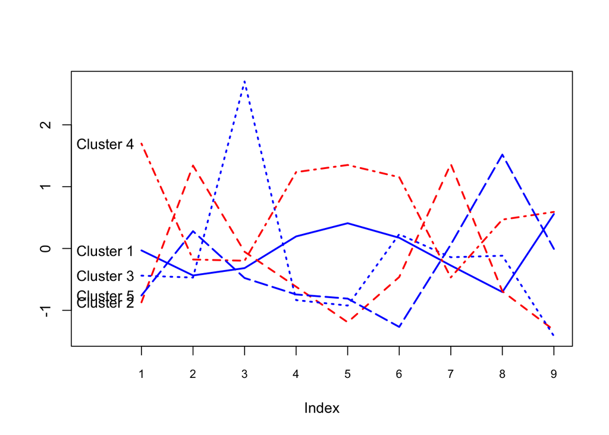

```r
plot(c(0), xaxt = 'n', ylab = "", type = "l",
     ylim = c(min(km$centers), max(km$centers)), xlim = c(0, 9))
axis(1, at = c(1:9), labels = names(df), cex.axis=.8)
for (i in c(1:5))
lines(km$centers[i,], lty = i, lwd = 2, col = ifelse(i %in% c(1, 3, 5),
                            "blue", "red"))
text(x = 0.3, y = km$centers[, 1], labels = paste("Cluster", c(1:5)))
```

Descriptions of each cluster: Cluster 1 = Low Beta, Low Rev_Growth, High Net_Profit_Margin (No extremes) Cluster 2 = Low Market_Cap, High Beta, Low ROA, High leverage Cluster 3 = High PE_Ratio, Low Net_Profit_Margin Cluster 4 = High Market_Cap, High ROE, High ROA, High Asset_Turnover, High Net_Profit_Margin Cluster 5 = Low PE_Ratio, Low Asset_Turnover

```r
km$centers #numerical descriptions of each cluster
```

```
##    Market Cap       Beta    PE_Ratio        ROE        ROA Asset_Turnover
## 1 -0.03142211 -0.4360989 -0.31724852  0.1950459  0.4083915      0.1729746
## 2 -0.87051511  1.3409869 -0.05284434 -0.6184015 -1.1928478     -0.4612656
## 3 -0.43925134 -0.4701800  2.70002464 -0.8349525 -0.9234951      0.2306328
## 4  1.69558112 -0.1780563 -0.19845823  1.2349879  1.3503431      1.1531640
## 5 -0.76022489  0.2796041 -0.47742380 -0.7438022 -0.8107428     -1.2684804
##      Leverage Rev_Growth Net_Profit_Margin
## 1 -0.27449312 -0.7041516       0.556954446
## 2  1.36644699 -0.6912914      -1.320000179
## 3 -0.14170336 -0.1168459      -1.416514761
## 4 -0.46807818  0.4671788       0.591242521
## 5  0.06308085  1.5180158      -0.006893899
```

```r
km$withinss #numerical descriptions of each cluster
```

```
## [1] 21.879320 15.595925  2.803505  9.284424 12.791257
```

```r
km$size #numerical descriptions of each cluster
```

```
## [1] 8 3 2 4 4
```

Clusters 3,4 are the most homogenous- also amongst the smallest clusters. The least homogenous is Cluster 1, coincidentally also the largest cluster.

```r
dist(km$centers)
```

```
##          1        2        3        4
## 2 3.711570
## 3 4.045579 3.775790
## 4 2.720924 5.457397 5.275301
## 5 3.299161 3.230532 4.210877 4.744753
```

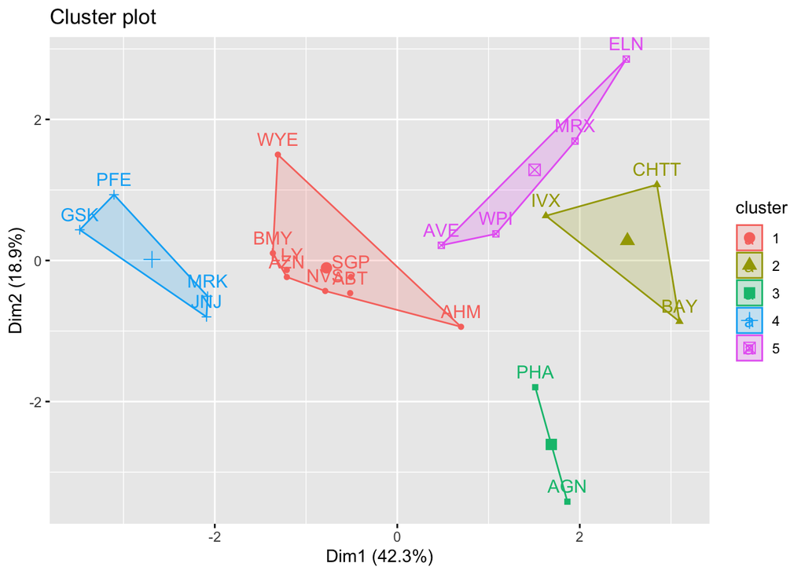

```r
fviz_cluster(km, data = df) # Visualize the output
```

Patterns among the clusters (categorical variables): Cluster 1: All traded on the NYSE, 5/8 of these are US companies Cluster 2: 2/3 of these are holds, 2/3 are US companies Cluster 3: Both listed on the NYSE Cluster 4: 2 are moderately buy, 2 are hold, 3/4 are US companies, all traded on NYSE Cluster 5: 2 Moderately sell, 2 moderately buy, all traded on NYSE

When it comes to the categorical variables, there’s definite trends in the dataset related to trading environment and location- however since US and NYSE dominate both categories, I don’t think these similiarities are related to the clustering. From the clusters that my model generated, there were no overhwhelming similarities when it came to the median_recommmendation for each company.

Names for each cluster: Cluster1: The_Middle_No_Extremes Cluster2: Low_Market_Cap_ROA_High_Beta_Leverage Cluster3: High_PE_Ratio_Low_Net_Profit_Margin Cluster4: High_Market_Cap_ROE_ROA_Asset_Turnover_Net_Profit_Margin Cluster5: Low_PE_Ratio_Asset_Turnover